# COVID-19 Data Analysis Report

Jayanth Kumar Enugala

10-10-2024

### Import Libraries

```r
library(tidyverse)
library(lubridate)
library(ggplot2)
library(dplyr)
library(scales)
library(forecast)
```

## Introduction

### Project Purpose: Analysis of COVID-19 Data from the Johns Hopkins

This project aims to analyze the COVID-19 dataset from the Johns Hopkins GitHub repository to gain insights into the pandemic’s progression and impact across different regions. By applying data science techniques, we seek to uncover patterns, trends, and relationships within the data.

### Objectives

- To clean and transform the raw COVID-19 data into a format suitable for analysis.
- To create informative visualizations that highlight key aspects of the pandemic’s spread and impact.
- To develop a predictive model for COVID-19 cases or deaths.
- To identify and discuss potential biases in the data and analysis.

### Question of Interest

- How does the case fatality rate (CFR) vary across different countries, and how has it changed over time?
- Can we predict future COVID-19 cases for a specific country using time series forecasting?

## Project Step 1: Describe and Import the Dataset

### Data Description

The dataset consists of four CSV files: - Global confirmed cases - Global deaths - US confirmed cases - US deaths

These files contain time series data of COVID-19 cases and deaths, reported at various geographical levels (country, state/province, and county for the US).

### Import Dataset

```r
url_in <- "https://raw.githubusercontent.com/CSSEGISandData/COVID-19/master/csse_covid_19_data/csse_covid_19_time_series/"

file_names <- c(
  "time_series_covid19_confirmed_global.csv",
  "time_series_covid19_deaths_global.csv",
  "time_series_covid19_confirmed_US.csv",
  "time_series_covid19_deaths_US.csv"
)

urls <- str_c(url_in, file_names)

global_cases <- read_csv(urls[1])
global_deaths <- read_csv(urls[2])
US_cases <- read_csv(urls[3])
US_deaths <- read_csv(urls[4])
```

### Step 2: Tidy and Transform Data

### Tidy Global Data

```r
global_cases <- global_cases %>%
  pivot_longer(cols = -c('Province/State', 'Country/Region', Lat, Long),
               names_to = "date",
               values_to = "cases")

global_deaths <- global_deaths %>%
  pivot_longer(cols = -c('Province/State', 'Country/Region', Lat, Long),
               names_to = "date",
               values_to = "deaths")

global <- global_cases %>%
  full_join(global_deaths) %>%
  rename(Country_Region = 'Country/Region',
         Province_State = 'Province/State') %>%
  mutate(date = mdy(date))
```

[output not shown]

### Tidy US Data

```r
US_cases <- US_cases %>%
  pivot_longer(cols = -(UID:Combined_Key),
               names_to = "date",
               values_to = "cases") %>%
  select(Admin2:cases) %>%
  mutate(date = mdy(date)) %>%
  select(-c(Lat, Long_))

US_deaths <- US_deaths %>%
  pivot_longer(cols = -(UID:Population),
               names_to = "date",
               values_to = "deaths") %>%
  select(Admin2:deaths) %>%
  mutate(date = mdy(date)) %>%
  select(-c(Lat, Long_))

US <- US_cases %>%
  full_join(US_deaths)
```

[output not shown]

### Calculate global case fatality rate

```r
global_cfr <- global %>%
  group_by(Country_Region, date) %>%
  summarize(total_cases = sum(cases),
            total_deaths = sum(deaths)) %>%
  mutate(cfr = total_deaths / total_cases * 100) %>%
  ungroup()
```

### Print summary statistics

```r
summary(global)
```

```
##  Province_State     Country_Region          Lat               Long
##  Length:330327      Length:330327      Min.   :-71.950   Min.   :-178.12
##  Class :character   Class :character   1st Qu.:  3.934   1st Qu.: -42.60
##  Mode  :character   Mode  :character   Median : 21.513   Median :  20.94
##                                        Mean   : 19.719   Mean   :  22.18
##                                        3rd Qu.: 40.464   3rd Qu.:  90.36
##                                        Max.   : 71.707   Max.   : 178.06
##                                        NA's   :2286      NA's   :2286
##       date                cases               deaths
##  Min.   :2020-01-22   Min.   :        0   Min.   :      0
##  1st Qu.:2020-11-02   1st Qu.:      680   1st Qu.:      3
##  Median :2021-08-15   Median :    14429   Median :    150
##  Mean   :2021-08-15   Mean   :   959384   Mean   :  13380
##  3rd Qu.:2022-05-28   3rd Qu.:   228517   3rd Qu.:   3032
##  Max.   :2023-03-09   Max.   :103802702   Max.   :1123836
##
```

```r
summary(US)
```

```
##     Admin2          Province_State     Country_Region     Combined_Key
##  Length:3819906     Length:3819906     Length:3819906     Length:3819906
##  Class :character   Class :character   Class :character   Class :character
##  Mode  :character   Mode  :character   Mode  :character   Mode  :character
##
##
##
##       date                cases           Population           deaths
##  Min.   :2020-01-22   Min.   :  -3073   Min.   :       0   Min.   :  -82.0
##  1st Qu.:2020-11-02   1st Qu.:    330   1st Qu.:    9917   1st Qu.:    4.0
##  Median :2021-08-15   Median :   2272   Median :   24892   Median :   37.0
##  Mean   :2021-08-15   Mean   :  14088   Mean   :   99604   Mean   :  186.9
##  3rd Qu.:2022-05-28   3rd Qu.:   8159   3rd Qu.:   64979   3rd Qu.:  122.0
##  Max.   :2023-03-09   Max.   :3710586   Max.   :10039107   Max.   :35545.0
```

```r
summary(global_cfr)
```

```
##  Country_Region          date             total_cases         total_deaths
##  Length:229743      Min.   :2020-01-22   Min.   :        0   Min.   :      0
##  Class :character   1st Qu.:2020-11-02   1st Qu.:     3831   1st Qu.:     46
##  Mode  :character   Median :2021-08-15   Median :    52933   Median :    786
##                     Mean   :2021-08-15   Mean   :  1379412   Mean   :  19238
##                     3rd Qu.:2022-05-28   3rd Qu.:   499592   3rd Qu.:   7227
##                     Max.   :2023-03-09   Max.   :103802702   Max.   :1123836
##
##       cfr
##  Min.   :0.000
##  1st Qu.:0.710
##  Median :1.452
##  Mean   :  Inf
##  3rd Qu.:2.470
##  Max.   :  Inf
##  NA's   :15628
```

### Visualizations and Analysis

### Calculate global average CFR

```r
global_avg_cfr <- global_cfr %>%
  group_by(date) %>%
  summarize(avg_cfr = mean(cfr, na.rm = TRUE))
```

### Plot global average CFR over time

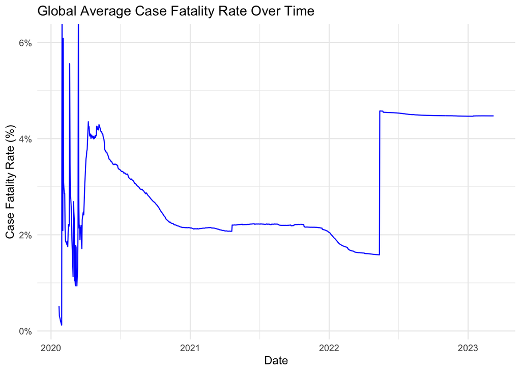

```r
ggplot(global_avg_cfr, aes(x = date, y = avg_cfr)) +
  geom_line(color = "blue") +
  labs(title = "Global Average Case Fatality Rate Over Time",
       x = "Date",
       y = "Case Fatality Rate (%)") +
  theme_minimal() +
  scale_y_continuous(labels = scales::percent_format(scale = 1))
```

### Case Fatality Rate Comparison Across Top 10 Countries

### Get the latest CFR for top 10 countries by total cases

```r
top_10_countries <- global_cfr %>%
  group_by(Country_Region) %>%
  summarize(total_cases = max(total_cases),
            latest_cfr = last(cfr)) %>%
  arrange(desc(total_cases)) %>%
  head(10)
```

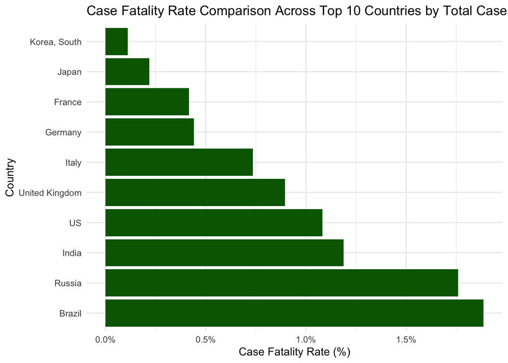

```r
### Plot CFR comparison
ggplot(top_10_countries, aes(x = reorder(Country_Region, -latest_cfr), y = latest_cfr)) +
  geom_bar(stat = "identity", fill = "darkgreen") +
  coord_flip() +
  labs(title = "Case Fatality Rate Comparison Across Top 10 Countries by Total Cases",
       x = "Country",
       y = "Case Fatality Rate (%)") +
  theme_minimal() +
  scale_y_continuous(labels = scales::percent_format(scale = 1))
```

This visualization compares the case fatality rates across the top 10 countries by total cases. We can see significant variations in CFR among these countries, which could be due to factors such as healthcare system capacity, testing strategies, demographic differences, and reporting practices.

### Time Series Forecasting for COVID-19 Cases in the United States

### Prepare US data for forecasting

```r
us_total_cases <- US %>%
  group_by(date) %>%
  summarize(total_cases = sum(cases)) %>%
  ungroup()
```

```r
### Create time series object
us_ts <- ts(us_total_cases$total_cases, frequency = 7)
```

```r
### Fit ARIMA model
us_model <- auto.arima(us_ts)
```

```r
### Generate forecast for the next 30 days
us_forecast <- forecast(us_model, h = 30)
```

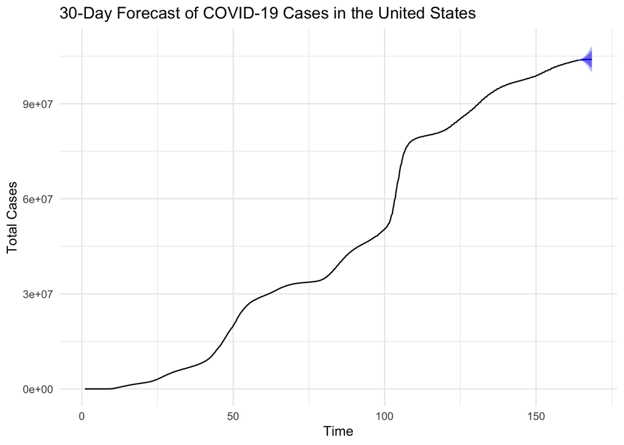

```r
### Plot the forecast
autoplot(us_forecast) +
  labs(title = "30-Day Forecast of COVID-19 Cases in the United States",
       x = "Time",
       y = "Total Cases") +
  theme_minimal()
```

```r
### Print model summary
summary(us_model)
```

```
## Series: us_ts
## ARIMA(4,1,5)(0,1,2)[7]
##
## Coefficients:
##          ar1     ar2     ar3      ar4      ma1      ma2      ma3     ma4
##       0.3489  1.2881  0.0235  -0.7035  -0.1326  -1.2573  -0.0130  0.7811
## s.e.  0.0529  0.0474  0.0449   0.0385   0.0616   0.0294   0.0724  0.0237
##           ma5     sma1    sma2
##       -0.1579  -0.3622  0.1243
## s.e.   0.0490   0.0406  0.0338
##
## sigma^2 = 1.594e+09:  log likelihood = -13631.98
## AIC=27287.96   AICc=27288.24   BIC=27348.38
##
## Training set error measures:
##                    ME    RMSE      MAE       MPE      MAPE       MASE
## Training set 16.39698 39589.2 17452.01 0.3643402 0.6184197 0.02731342
##                      ACF1
## Training set 0.0007847328
```

This ARIMA model provides a 30-day forecast of COVID-19 cases in the United States. The forecast shows the expected trend along with prediction intervals, giving us an idea of the potential range of future cases.

### Sources of Bias:

Several potential sources of bias should be considered when interpreting these results:

- Reporting bias: Different countries have varying capacities and methods for testing and reporting COVID-19 cases and deaths. This can lead to under-reporting or inconsistent reporting across regions.
- Testing bias: The number of confirmed cases is heavily dependent on testing capacity and policies, which have varied greatly across countries and over time.
- Time lag bias: There’s often a delay between infection, symptom onset, testing, and reporting, which can affect the accuracy of daily case counts and death reports.
- Demographic bias: Our analysis doesn’t account for demographic factors such as age distribution, underlying health conditions, or socioeconomic status, which can significantly impact COVID-19 outcomes.
- Healthcare system bias: Differences in healthcare system capacity and quality across countries can affect both case detection and mortality rates.
- Policy bias: Government interventions and policies (e.g., lockdowns, mask mandates) vary across regions and time, influencing the spread and impact of the virus.
- Model simplification bias: Our time series model assumes that past trends will continue into the future and doesn’t account for potential changes in virus behavior, human behavior, or interventions.
- Data aggregation bias: By analyzing data at the country level, we may miss important local variations within countries.

To mitigate these biases, future analyses could incorporate additional data sources, use more sophisticated modeling techniques, and consider a wider range of factors that influence COVID-19 spread and impact. It’s crucial to interpret the results cautiously and in the context of these potential biases.